# Sampling and Iteration in the Tidyverse

j4yr0u93

9/20/2020

# 1

```
## # A tibble: 6 x 8
##   species island bill_length_mm bill_depth_mm flipper_length_~ body_mass_g sex
##   <fct>   <fct>           <dbl>         <dbl>            <int>       <int> <fct>
## 1 Adelie  Torge~           39.1          18.7              181        3750 male
## 2 Adelie  Torge~           39.5          17.4              186        3800 fema~
## 3 Adelie  Torge~           40.3          18                195        3250 fema~
## 4 Adelie  Torge~           NA            NA                 NA          NA <NA>
## 5 Adelie  Torge~           36.7          19.3              193        3450 fema~
## 6 Adelie  Torge~           39.3          20.6              190        3650 male
## # ... with 1 more variable: year <int>
```

```
## tibble [344 x 8] (S3: tbl_df/tbl/data.frame)
##  $ species          : Factor w/ 3 levels "Adelie","Chinstrap",..: 1 1 1 1 1 1 1 1 1 1 ...
##  $ island           : Factor w/ 3 levels "Biscoe","Dream",..: 3 3 3 3 3 3 3 3 3 3 ...
##  $ bill_length_mm   : num [1:344] 39.1 39.5 40.3 NA 36.7 39.3 38.9 39.2 34.1 42 ...
##  $ bill_depth_mm    : num [1:344] 18.7 17.4 18 NA 19.3 20.6 17.8 19.6 18.1 20.2 ...
##  $ flipper_length_mm: int [1:344] 181 186 195 NA 193 190 181 195 193 190 ...
##  $ body_mass_g      : int [1:344] 3750 3800 3250 NA 3450 3650 3625 4675 3475 4250 ...
##  $ sex              : Factor w/ 2 levels "female","male": 2 1 1 NA 1 2 1 2 NA NA ...
##  $ year             : int [1:344] 2007 2007 2007 2007 2007 2007 2007 2007 2007 2007 ...
```

```
##       species          island    bill_length_mm  bill_depth_mm
##  Adelie   :152   Biscoe   :168   Min.   :32.10   Min.   :13.10
##  Chinstrap: 68   Dream    :124   1st Qu.:39.23   1st Qu.:15.60
##  Gentoo   :124   Torgersen: 52   Median :44.45   Median :17.30
##                                  Mean   :43.92   Mean   :17.15
##                                  3rd Qu.:48.50   3rd Qu.:18.70
##                                  Max.   :59.60   Max.   :21.50
##                                  NA's   :2       NA's   :2
##  flipper_length_mm  body_mass_g       sex           year
##  Min.   :172.0     Min.   :2700   female:165   Min.   :2007
##  1st Qu.:190.0     1st Qu.:3550   male  :168   1st Qu.:2007
##  Median :197.0     Median :4050   NA's  : 11   Median :2008
##  Mean   :200.9     Mean   :4202                Mean   :2008
##  3rd Qu.:213.0     3rd Qu.:4750                3rd Qu.:2009
##  Max.   :231.0     Max.   :6300                Max.   :2009
##  NA's   :2         NA's   :2
```

# 2a

```
## [1] "our vector is c(1,4,7,NA,9)"
```

```
## [1] "mean(vector) produces:"
```

```
## [1] NA
```

```
## [1] "whereas mean(vector, na.rm=TRUE) produces:"
```

```
## [1] 5.25
```

# 2b-d

```
## [1] "Standard stats of penguin body mass are:"
```

| target | count | sd | mean | median |
| --- | --- | --- | --- | --- |
| Adelie | 152 | 458.5661 | 3700.6623 | 3700 |
| Gentoo | 124 | 504.1162 | 5076.0163 | 5000 |
| Chinstrap | 68 | 384.3351 | 3733.0882 | 3700 |
| All Penguins | 344 | 801.9545 | 4201.7544 | 4050 |
| Biscoe Island | 168 | 782.8557 | 4716.018 | 4775 |

Gentoo penguins have highest mean mass compared to Chinstrap and Adelie, Gentoo on average weigh more then. Chinstrap Penguins have a similar mean and the same median mass value to Adelie penguins, but have a tighter distribution of masses since they have a smaller sd. When looking at biscoe island and all penguins combined, we can assume that biscoe island is closer to having a distribution of more than one species, and we know that Gentoo are present since the mean and median are greater than the exclusively Chinstrap and Adelie populations.

# 2e

```
## tibble [344 x 9] (S3: tbl_df/tbl/data.frame)
##  $ species          : Factor w/ 3 levels "Adelie","Chinstrap",..: 1 1 1 1 1 1 1 1 1 1 ...
##  $ island           : Factor w/ 3 levels "Biscoe","Dream",..: 3 3 3 3 3 3 3 3 3 3 ...
##  $ bill_length_mm   : num [1:344] 39.1 39.5 40.3 NA 36.7 39.3 38.9 39.2 34.1 42 ...
##  $ bill_depth_mm    : num [1:344] 18.7 17.4 18 NA 19.3 20.6 17.8 19.6 18.1 20.2 ...
##  $ flipper_length_mm: int [1:344] 181 186 195 NA 193 190 181 195 193 190 ...
##  $ body_mass_g      : int [1:344] 3750 3800 3250 NA 3450 3650 3625 4675 3475 4250 ...
##  $ sex              : Factor w/ 2 levels "female","male": 2 1 1 NA 1 2 1 2 NA NA ...
##  $ year             : int [1:344] 2007 2007 2007 2007 2007 2007 2007 2007 2007 2007 ...
##  $ species-island   : Factor w/ 5 levels "Adelie_Biscoe",..: 3 3 3 3 3 3 3 3 3 3 ...
```

```
## [1] Adelie_Torgersen Adelie_Biscoe    Adelie_Dream     Gentoo_Biscoe
## [5] Chinstrap_Dream
## 5 Levels: Adelie_Biscoe Adelie_Dream Adelie_Torgersen ... Gentoo_Biscoe
```

Looking at our ‘species-island’ factor confirms that Gentoo and Adelie are both present on Biscoe island which explains the mean, median, and sd values above. It also tell use Adelie exist on their own island, an island with Chinstrap, and an island with Gentoo.

# 3a

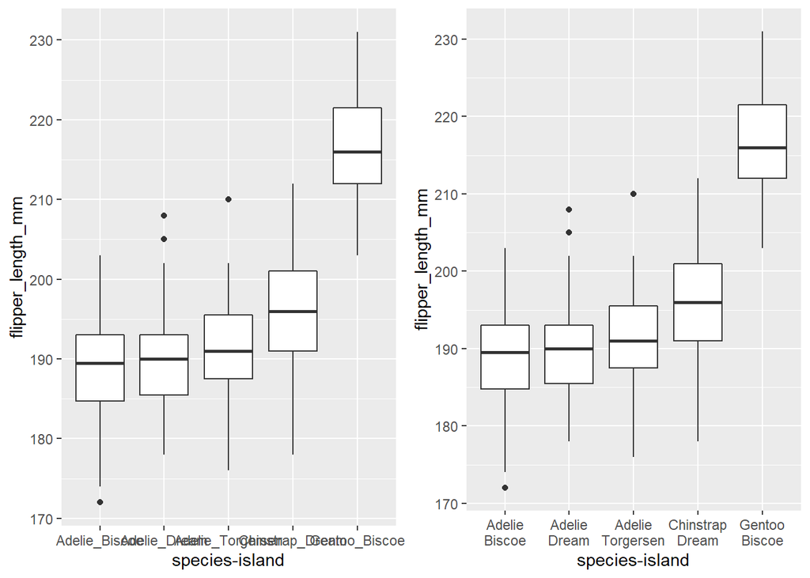

# 3b-c

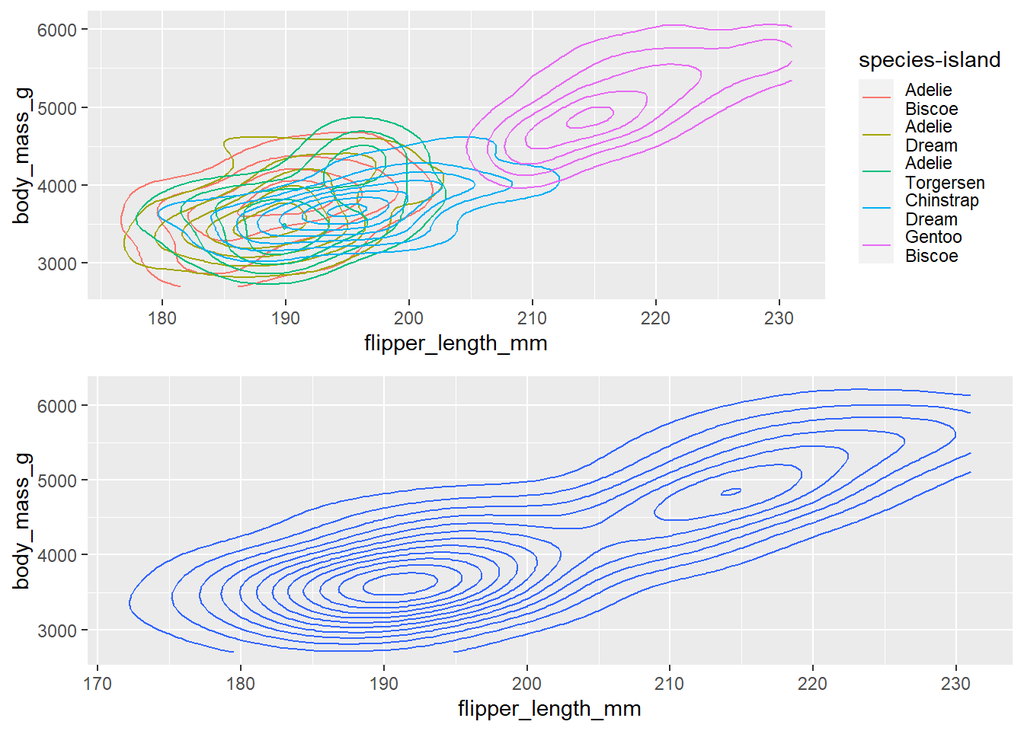

It seems like there are 2 grouping for the relationship between flipper length and body mass when looking at the density plot of species vs combined species. Adelie and Chinstrap for the most part fall in the same grouping and Gentoo is the only very visually distinct group.

# 4a-b

```
## [1] "bisgent_sem <- replicate(10, sd(bisgent)/sqrt(length(bisgent)))"
```

```
##  [1] 0.2778817 0.2778817 0.2778817 0.2778817 0.2778817 0.2778817 0.2778817
##  [8] 0.2778817 0.2778817 0.2778817
```

If we sample `bisgent` our Biscoe Gentoo `bill_length_mm` col taking the mean 10 times, we get a mean standard error of ~0.28.

# 4c-d

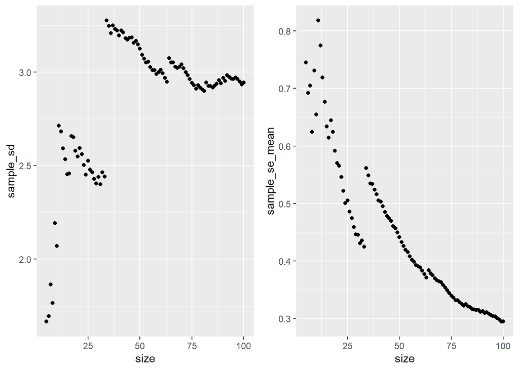

Laymans understanding of these plots is that as more values are added we approach the actual SD and SE of mean, the jump being from an anomaly value at bisgent[34] equal to 59.6 mm and then a return to a tighter SE of mean and closer approximation of SD. SE of mean ultimately is affected less by the outlier since it is a measure of mean confidence whereas SD is more heavily affected by the outlier since it is a measure of the variability or precision of the data altogether.

# git extra credit

pushed my repo and submitting the whole repo as hw  
[HW_2 github link](https://github.com/j4yr0u93/HW_2)